```python
from IPython.core.display import display, HTML
display(HTML("<style>.container { width:90% !important; }</style>"))
```

# The influence of New Zealand wine on global market

### Zoe Wang

#### 2018.08.12

Table of Contents

- Overview datasets of wine review
  - 1.1 General Statistics
    - Percentage of different country wine
    - point&price
    - Global popular variety of wine
  - 1.2 Summarys of New Zealand Wine
    - NZ popilar variety
    - Relation of points and price
    - The percentage of different region wine production
    - Comparison of the number of New Zealand wineries

### Datasets originally and Purpose

This dataset is public available for research. The details are described in Kaggle https://www.kaggle.com/zynicide/wine-reviews, The last updated is 8 month ago, should be early 2018. I belive the owner of this dataset scraped all the information on twitter. The purpose of this datasets analysis is to discuss the impact of New Zealand wine product on the globe market. In this rearch i will look at integrate information on global wines, including variety, origins, points and price, and then analyze whether New Zealand wines differences with international wine development.

### summary

This data set comes from the web crawler in twitter that include wine rating, price, region, winery and so on information, and there are many imperfections. I hope to find the advantages and disadvantages of New Zealand wine through the above data. From the sample data, it can be seen that the United States is still a big country in wine consumption and production, with high-end and medium-end wine as the mainstay, while France as the old wine producing area still accounts for the score and price. New Zealand is a new wine exporter. Its history is not as long as France, Italy and other countries, but it has a unique natural advantage, the wine winery is spread all over the country, and the main wines grown and brewed are in line with international fashion, mainly based on Sauvignon Blanc, Pinot Noir, Chardonnay and mixed wines, also she is very promising in the future.

### During this research i will discuss those questions:

1. Genuinely view of the proportion of global wine consumption and production.
2. Understand the price of global wines and the relationship between prices and points especially in NZ wine points and price.
3. Observe the main popular wine varieties and the main varieties of New Zealand wine, and consider whether New Zealand wine is in line with international mainstream.
4. Find the proportion of New Zealand wine in global market, through dataset samples, analyze geographic location and the potential of New Zealand wineries.

Description of attributes:

Wine review:

1. country: The country that the wine is from
2. description: A few sentences from a sommelier describing the wine's taste, smell, look, feel, etc.
3. designation: The vineyard within the winery where the grapes that made the wine are from
4. points: The number of points WineEnthusiast rated the wine on a scale of 1-100 (though they say they only post reviews for wines that score >=80)
5. price: The cost for a bottle of the wine
6. provinceThe province or state that the wine is from
7. region_1: The wine growing area in a province or state (ie Napa)
8. region_2: Sometimes there are more specific regions specified within a wine growing area (ie Rutherford inside the Napa Valley), but this value can sometimes be blank
9. taster_name: Name of the person who tasted and reviewed the wine
10. taster_twitter_handle: Twitter handle for the person who tasted and reviewed the wine
11. title: The title of the wine review, which often contains the vintage if you're interested in extracting that feature
12. varietyThe type of grapes used to make the wine (ie Pinot Noir)
13. wineryThe winery that made the wine

## Import all the library

```python
import pandas as pd
import numpy as np
import matplotlib.pyplot as plt
import seaborn as sns
```

```python
from pylab import rcParams

rcParams['figure.dpi'] = 350
rcParams['lines.linewidth'] = 2
rcParams['axes.facecolor'] = 'white'
rcParams['patch.edgecolor'] = 'white'
rcParams['font.family'] = 'StixGeneral'
rcParams['figure.figsize'] = 10,8
rcParams['font.size'] = 18

rcParams['axes.labelsize'] = 'medium'
rcParams['xtick.labelsize'] = 8
rcParams['ytick.labelsize'] = 8
```

```python
#this line enables the plots to be embedded into the notebook
%matplotlib inline
```

```python
# Set some Pandas options for displaying the data as you like
pd.set_option('max_columns', 8)
pd.set_option('max_rows', 8)
pd.set_option('notebook_repr_html', True)
```

```python
import matplotlib
import matplotlib.pyplot as plt
import pandas as pd
import numpy as np
```

```python
import seaborn as sns
sns.set(style="ticks", font_scale=16)
```

```python
from pylab import rcParams
```

```python
matplotlib.style.use('ggplot')
```

## Import Datasets

```python
location_review_first = "F:\python data analysis\datasets\wine\winemag-data_first150k.csv"
location_review_second = "F:\python data analysis\datasets\wine\winemag-data-130k-v2.csv"

#wine_data_rv1 = pd.read_csv(location_review_first, iterator = True)
#wine_data_rv2 = pd.read_csv(location_review_second, iterator = True)
wine_data_rv1 = pd.read_csv(location_review_first)
wine_data_rv2 = pd.read_csv(location_review_second)

# use chunksize, make a iterator and set it true than use .get_chunk(chunk number) can separet file to different block and show first five
#winedatafile_first = wine_data_rv1.get_chunk(1000)
#winedatafile_second = wine_data_rv2.get_chunk(1000)

#print(winedatafile_first)
#print(winedatafile_second)

#wine_data1.info()
```

## 1.1 Overview of the datasets

In this place we can simply see the entire data information including the total amount of data and EDA information, while I deal with the missing data at here, replace the missing string data with none, replace the missing numbers Becomes 0, also i remove some useless data such as taster_name, aster_twitter_handle and so on, you can see below.

```python
#wine_reviw_list_test = pd.merge(winedatafile_first, winedatafile_second, on='country')
#Concat two dataframes in one table
wine_reviw_list = pd.concat([wine_data_rv1, wine_data_rv2], ignore_index=True, sort=True)

#Remove useless columns from dataframe
wine_reviw_list.drop(columns=['taster_name', 'description', 'taster_twitter_handle', 'title', 'Unnamed: 0', 'region_2'], inplace=True)

#Remove missing data NAN from designation and region_1
value = {'designation': 'none', 'region_1':'none', 'price':0}
Nwe_wine_reviw = wine_reviw_list.fillna(value=value)
Nwe_wine_reviw.head()
```

|  | country | designation | points | price | province | region_1 | variety | winery |
| --- | --- | --- | --- | --- | --- | --- | --- | --- |
| 0 | US | Martha's Vineyard | 96 | 235.0 | California | Napa Valley | Cabernet Sauvignon | Heitz |
| 1 | Spain | Carodorum Selección Especial Reserva | 96 | 110.0 | Northern Spain | Toro | Tinta de Toro | Bodega Carmen Rodríguez |
| 2 | US | Special Selected Late Harvest | 96 | 90.0 | California | Knights Valley | Sauvignon Blanc | Macauley |
| 3 | US | Reserve | 96 | 65.0 | Oregon | Willamette Valley | Pinot Noir | Ponzi |
| 4 | France | La Brûlade | 95 | 66.0 | Provence | Bandol | Provence red blend | Domaine de la Bégude |

```python
Nwe_wine_reviw.pivot_table(values={'points', 'price'}, index=['variety'], aggfunc=[ np.median, np.max, np.min]).head(8)
```

| variety | median points | median price | amax points | amax price | amin points | amin price |
| --- | --- | --- | --- | --- | --- | --- |
| Abouriou | 87.0 | 15.0 | 91 | 75.0 | 85 | 15.0 |
| Agiorgitiko | 86.0 | 17.0 | 92 | 66.0 | 81 | 0.0 |
| Aglianico | 89.0 | 25.0 | 97 | 180.0 | 81 | 0.0 |
| Aidani | 82.0 | 27.0 | 82 | 27.0 | 82 | 27.0 |
| Airen | 82.0 | 9.0 | 83 | 10.0 | 80 | 8.0 |
| Albana | 90.0 | 20.0 | 94 | 66.0 | 84 | 0.0 |
| Albanello | 86.0 | 20.0 | 86 | 20.0 | 86 | 20.0 |
| Albariño | 88.0 | 19.0 | 94 | 110.0 | 80 | 0.0 |

```python
Nwe_wine_reviw.shape
```

```
(280901, 8)
```

```python
Nwe_wine_reviw.describe()
```

|  | points | price |
| --- | --- | --- |
| count | 280901.000000 | 280901.000000 |
| mean | 88.146934 | 31.416353 |
| std | 3.151528 | 38.172862 |
| min | 80.000000 | 0.000000 |
| 25% | 86.000000 | 15.000000 |
| 50% | 88.000000 | 23.000000 |
| 75% | 90.000000 | 40.000000 |
| max | 100.000000 | 3300.000000 |

```python
Nwe_wine_reviw.info()
```

```
<class 'pandas.core.frame.DataFrame'>
RangeIndex: 280901 entries, 0 to 280900
Data columns (total 8 columns):
country        280833 non-null object
designation    280901 non-null object
points         280901 non-null int64
price          280901 non-null float64
province       280833 non-null object
region_1       280901 non-null object
variety        280900 non-null object
winery         280901 non-null object
dtypes: float64(1), int64(1), object(6)
memory usage: 17.1+ MB
```

## 1.1 General Statistics

```
Text(0.5,1,'Percentage of different country wine')
```

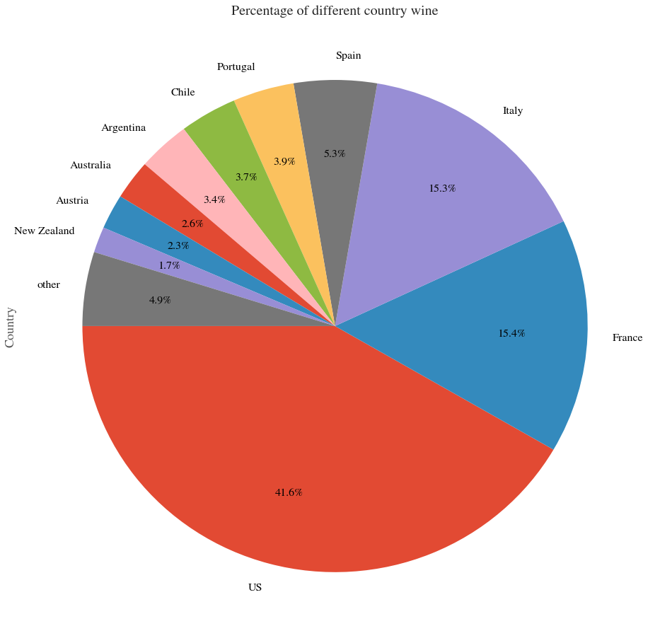

```python
#group all the country information from wine review datasets
country_review = Nwe_wine_reviw['country'].groupby(Nwe_wine_reviw['country']).count()
top_10_country = country_review.sort_values(ascending=False).head(10)
other_country_perc = country_review.sum()-top_10_country.sum()

#created new array for other country whom also have small size quangtity wine
data = np.array(other_country_perc)
other_country_review = pd.Series(data, index=['other'])

#add other country series to top 10 country
new_country = top_10_country.append(other_country_review)

#count percentage of those data
country_pcts = new_country/new_country.sum()*100

#create pie chart plot
country_pcts.plot.pie(
                        y='mass',
                        figsize=(16, 16),
                        pctdistance = 0.7,
                        autopct = '%3.1f%%',
                        labeldistance = 1.1,
                        startangle = 180,
                        textprops = {'fontsize':16, 'color':'K'}
)
plt.ylabel('Country', fontsize=18)
plt.title('Percentage of different country wine', fontsize=20)
```

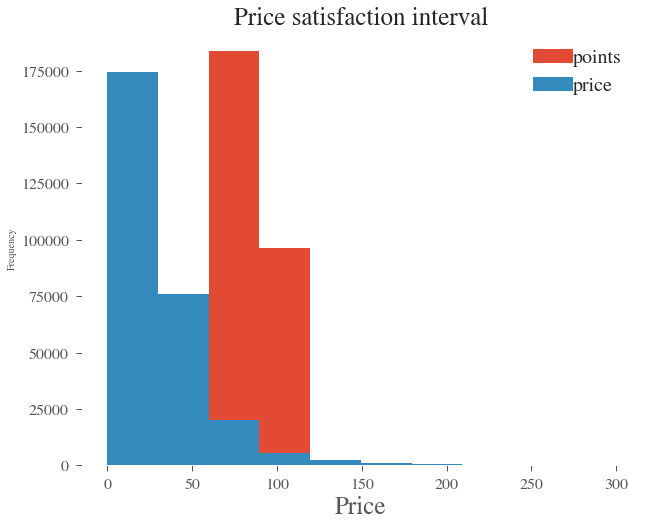

```python
Nwe_wine_reviw[Nwe_wine_reviw['price']<300].plot(kind='hist', title='price', figsize=(10, 8), fontsize='16')
plt.xlabel('Price', fontsize='25')
plt.title('Price satisfaction interval', fontsize='25')
ax = plt.gca()
ax.legend(handletextpad=0,loc='upper right', fontsize=20)
```

```
Text(0.5,1,'Price and Points Regression')
```

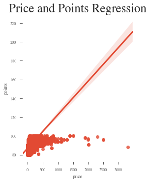

```python
sns.pairplot(wine_reviw_list, x_vars=['price'], y_vars='points', size=5, aspect=0.8, kind='reg')
plt.title('Price and Points Regression', fontsize='25')
```

As the data show below we can check which is most popular wine variety of global market. Pinot Noir are most popular in the red wine market, second one is chardonnay. The origin of Pinot Noir both in the Burgundy region of France, however is not limited grown in France but United States, Germany, Switzerland, New Zealand, Australia, Italy, Chile, South Africa and other regions. New Zealand also is the main growing area of Pinot Noir including Wairarapa, Masterton, Gladstone and Martinborough.

```
Text(0.5,1,'Global popular variety of wine')
```

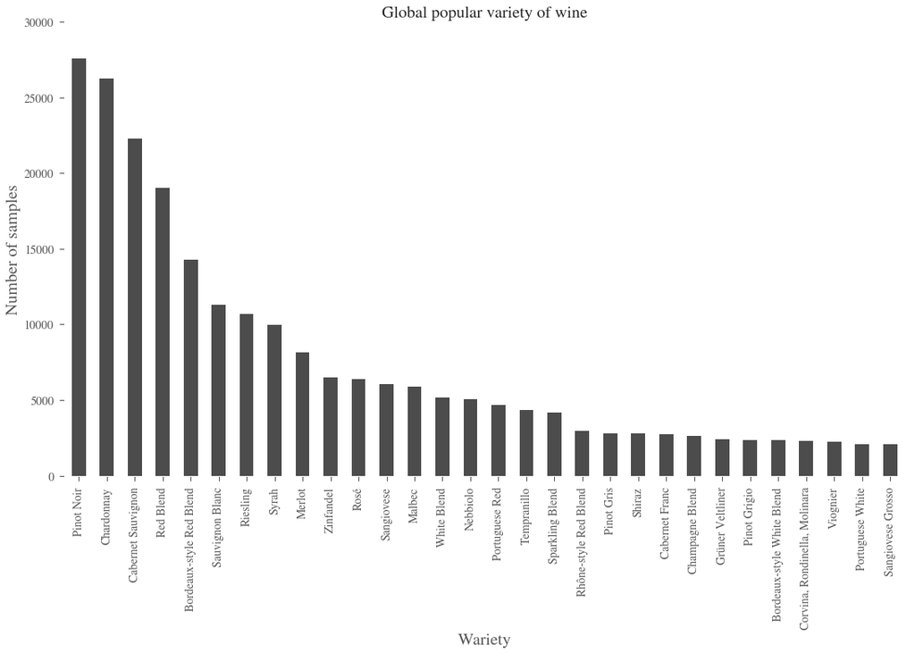

```python
#Groupby wine variety get top 30 popular variety
wine_variety = Nwe_wine_reviw['variety'].groupby(Nwe_wine_reviw['variety']).count()
wine_variety_numb = wine_variety.sort_values(ascending=False).head(30)
wine_variety_numb.plot(kind='bar', color='k', alpha=0.7, fontsize='14', title='10', figsize=(18, 10))
plt.ylim(ymax = 30000)
plt.xlabel('Wariety', fontsize=20)
plt.ylabel('Number of samples', fontsize=20)
plt.title('Global popular variety of wine', fontsize=20)
```

## 1.2 Summarys of New Zealand Wine

Over view New Zealand wine detail information. Focus on the New Zealand wine market advantages variety, winery, region and disadvantages of the price, points area.

```python
NZ_wine_review = Nwe_wine_reviw.loc[Nwe_wine_reviw['country']=='New Zealand']
NZ_wine_qulity = NZ_wine_review.sort_values(by=['points', 'price'], ascending=False, na_position='last')
NZ_wine_qulity.head(8)
```

|  | country | designation | points | price | province | region_1 | variety | winery |
| --- | --- | --- | --- | --- | --- | --- | --- | --- |
| 242781 | New Zealand | Homage | 95 | 100.0 | Hawke's Bay | none | Syrah | Trinity Hill |
| 273437 | New Zealand | SQM Gimblett Gravels Cabernets/Merlot | 95 | 79.0 | Hawke's Bay | none | Bordeaux-style Red Blend | Squawking Magpie |
| 155553 | New Zealand | Coleraine | 94 | 85.0 | Hawke's Bay | none | Bordeaux-style Red Blend | Te Mata |
| 273447 | New Zealand | Chosen Rows | 94 | 75.0 | Marlborough | none | Sauvignon Blanc | Brancott |
| 239623 | New Zealand | Kupe Single Vineyard | 94 | 69.0 | Martinborough | none | Pinot Noir | Escarpment |
| 25 | New Zealand | Maté's Vineyard | 94 | 57.0 | Kumeu | none | Chardonnay | Kumeu River |
| 305 | New Zealand | Maté's Vineyard | 94 | 57.0 | Kumeu | none | Chardonnay | Kumeu River |
| 246382 | New Zealand | none | 94 | 55.0 | Martinborough | none | Pinot Noir | Ata Rangi |

Add US wine information to a comparison

```python
US_wine_review = Nwe_wine_reviw.loc[Nwe_wine_reviw['country']=='US']
US_wine_qulity = US_wine_review.sort_values(by=['points', 'price'], ascending=False, na_position='last')
US_wine_qulity.head(8)
```

|  | country | designation | points | price | province | region_1 | variety | winery |
| --- | --- | --- | --- | --- | --- | --- | --- | --- |
| 268988 | US | La Muse | 100 | 450.0 | California | Sonoma County | Bordeaux-style Red Blend | Verité |
| 114272 | US | Red Wine | 100 | 245.0 | California | Rutherford | Cabernet Blend | Sloan |
| 143522 | US | Red Wine | 100 | 245.0 | California | Rutherford | Cabernet Blend | Sloan |
| 92916 | US | Hillside Select | 100 | 215.0 | California | Stags Leap District | Cabernet Sauvignon | Shafer |
| 89399 | US | none | 100 | 200.0 | California | Napa Valley | Cabernet Sauvignon | Cardinale |
| 137099 | US | none | 100 | 200.0 | California | Napa Valley | Cabernet Sauvignon | Cardinale |
| 196728 | US | none | 100 | 200.0 | California | Napa Valley | Cabernet Sauvignon | Cardinale |
| 98647 | US | Litton Estate Vineyard | 100 | 100.0 | California | Russian River Valley | Pinot Noir | Williams Selyem |

```python
US_wine_qulity.tail(8)
```

[output not shown]

```
Text(0.5,0,'variety')
```

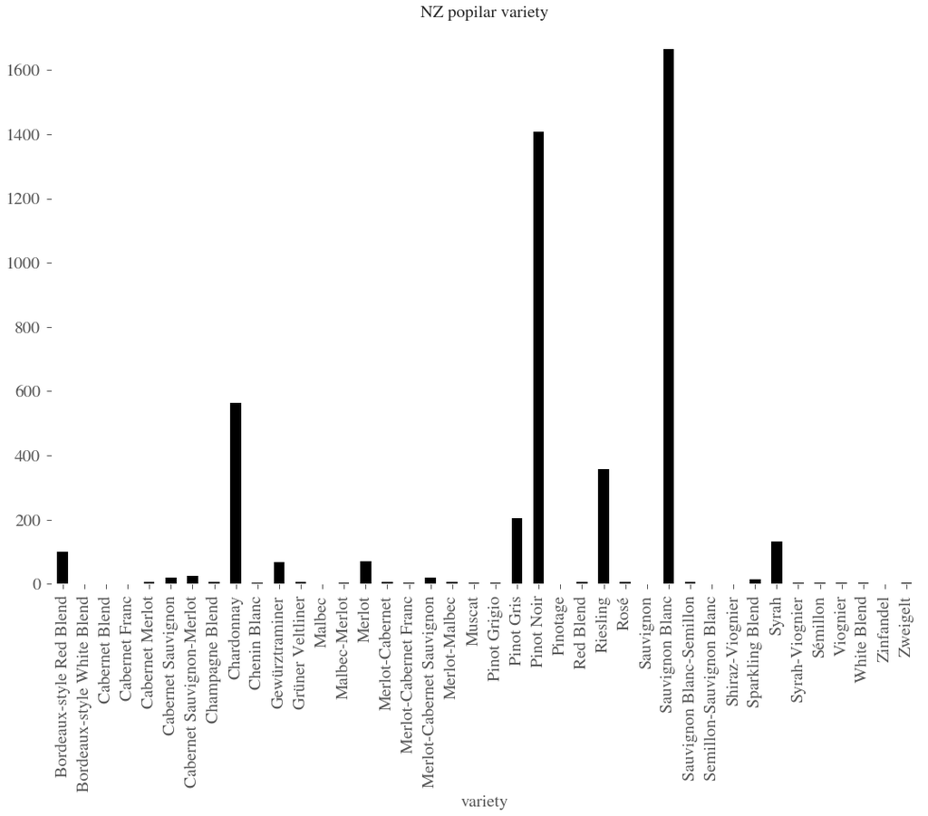

```python
variety_wine = NZ_wine_review['variety'].groupby(NZ_wine_review['variety']).count()
variety_wine.plot(kind='bar', title='variety', figsize=(18, 12), fontsize='20', color='k')
plt.title('NZ popilar variety', fontsize=20)
plt.xlabel('variety', fontsize=20)
```

This plot will show the relation between NZ wine points and price, in the chart we can see there are large discrepancy between price and points especially in range of 91 to 100 this point. I think the price difference between wine in the range of 0-40 is small.

```
Text(0.5,0,'Points')
```

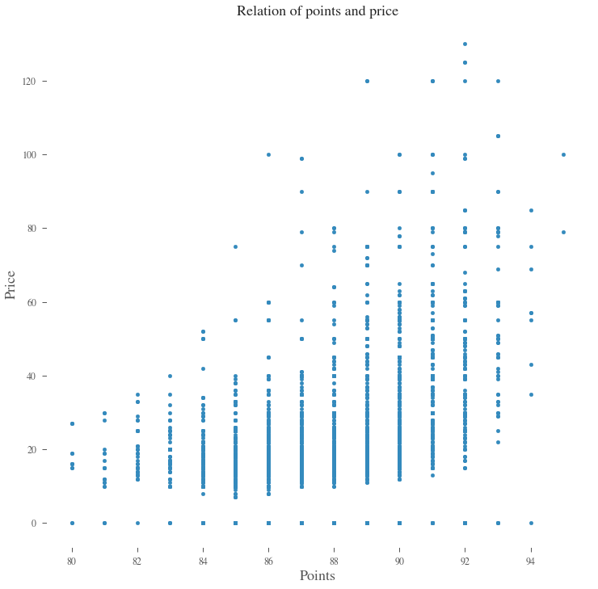

```python
NZ_wine_qulity.plot(kind='scatter', x='points', y='price', figsize=(12, 12), fontsize='12')
plt.title('Relation of points and price', fontsize=18)
plt.ylabel('Price', fontsize=18)
plt.xlabel('Points', fontsize=18)
```

The picture shows New Zealand's largest wine producing region is Marlborough followed by Hawke's Bay and Central Otago. Marlborough's wine production accounts for more than half of the country's which is 53.8%. After checking the map, the three major wine producing areas cover more than 50% of New Zealand's land area.

```
Text(0.5,1,'The percentage of different region wine production')
```

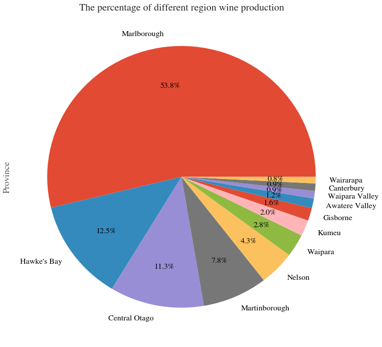

```python
province_wine = NZ_wine_review['province'].value_counts()
province_wine[province_wine>35].plot.pie(
                        y='mass',
                        figsize=(12, 12),
                        pctdistance = 0.7,
                        autopct = '%3.1f%%',
                        labeldistance = 1.1,
                        startangle = 0,
                        textprops = {'fontsize':16, 'color':'K'}
)
plt.ylabel('Province', fontsize=18)
plt.title('The percentage of different region wine production', fontsize=20)
```

From the sample data, it can be seen that the overall sales of New Zealand wineries are significantly different, with a wider audience of Saint Clair and Villa Maria products.

```
Text(0.5,0,'Winery')
```

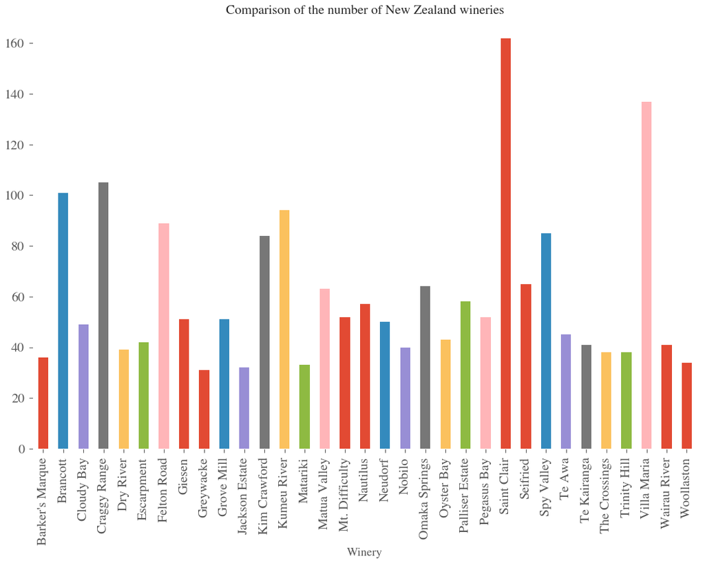

```python
winery_wine = NZ_wine_review['winery'].groupby(NZ_wine_review['winery']).count()
winery_wine[winery_wine>30].plot(kind='bar', title='winery', figsize=(18, 12), fontsize='20')
plt.title('Comparison of the number of New Zealand wineries', fontsize=20)
plt.xlabel('Winery', fontsize=18)
```